# Kaggle Europe Soccer

Nadira ABIDE, Olivier EKAMBI, Simon GRIMAL

28 avril 2018

# Description de l’étude

Nous utilisons une base de données en libre accès sur le football (https://www.kaggle.com/hugomathien/soccer). Cette base de données disponible sous format SQLite contient des informations sur les ligues de football de 11 pays européens pour les saisons 2008/2009 à 2015/2016. L’unité statistique est le match, la base contient pres de 25 000 matchs avec des informations relatives à la constitution des équipes ‘home’ et ‘away’, au positionnement des joueurs sur le terrain et aux quotes d’une demi douzaine de bookmakers. En supplément des informations relatives aux matchs, la base contient aussi des informations relatives aux qualités techniques des équipes et des joueurs.

Nous nous intéressons au résultat du match comme variable de supervision et comparons différents modèles de machine learning dans un but de classification.

## Les données

Les données:

```
+25,000 matchs
+10,000 joueurs
11 ligues européennes
Saisons 2008/2009 à 2015/20162016
Attributs d'équipes et de joueurs proviennent du jeu vidéo  'EA Sports FIFA'
Données de bookmakers provenant de 10 fournisseurs
```

## Protocole de modélisation

### Variable à expliquer : Y

Pour chacun des modèle nous voulons prévoir l’issue du match suivant et considérons deux variables explicatives :

- Deux modalités : Victoire à domicile (probabilité a priori de 46%) et absence de victoire à domicile (probabilité a priori de 54%).

```r
table(MCPT$goal_diff_class2)
```

```
##
## 1home_draworloss        2home_win
##            11047             9416
```

- Trois modalités : Victoire à domicile (46%), match nul (25%) et défaite à domicile (29%)

```r
table(MCPT$goal_diff_class3)
```

```
##
## 1home_loss      2draw  3home_win
##       5891       5156       9416
```

### Variables explicatives : X

L’unité statistique retenue est le match et nous utilisons une centaine de variables explicatives relatives aux deux équipes qui s’affrontent sur le terrain. Les données explicatives sont regroupées en quatre catégories :

- Quotes de différents bookmakers (B365 = Bet365, BW = Bet&Win, IW = Blue Square, LB = Ladbrokes H = Home, D = Draw, A = Away)

```r
summary(MCPT[,6:17])
```

```
##      B365H            B365D            B365A            BWH
##  Min.   : 1.040   Min.   : 1.530   Min.   : 1.08   Min.   : 1.030
##  1st Qu.: 1.670   1st Qu.: 3.250   1st Qu.: 2.50   1st Qu.: 1.670
##  Median : 2.100   Median : 3.500   Median : 3.50   Median : 2.100
##  Mean   : 2.629   Mean   : 3.841   Mean   : 4.68   Mean   : 2.561
##  3rd Qu.: 2.800   3rd Qu.: 4.000   3rd Qu.: 5.25   3rd Qu.: 2.750
##  Max.   :26.000   Max.   :17.000   Max.   :51.00   Max.   :34.000
##       BWD              BWA              IWH              IWD
##  Min.   : 1.650   Min.   : 1.100   Min.   : 1.050   Min.   : 1.500
##  1st Qu.: 3.200   1st Qu.: 2.500   1st Qu.: 1.650   1st Qu.: 3.200
##  Median : 3.400   Median : 3.400   Median : 2.100   Median : 3.300
##  Mean   : 3.751   Mean   : 4.414   Mean   : 2.471   Mean   : 3.615
##  3rd Qu.: 3.800   3rd Qu.: 5.000   3rd Qu.: 2.600   3rd Qu.: 3.700
##  Max.   :19.500   Max.   :51.000   Max.   :20.000   Max.   :11.000
##       IWA              LBH              LBD              LBA
##  Min.   : 1.100   Min.   : 1.040   Min.   : 1.440   Min.   : 1.100
##  1st Qu.: 2.500   1st Qu.: 1.670   1st Qu.: 3.200   1st Qu.: 2.500
##  Median : 3.300   Median : 2.100   Median : 3.400   Median : 3.400
##  Mean   : 4.164   Mean   : 2.538   Mean   : 3.716   Mean   : 4.397
##  3rd Qu.: 4.600   3rd Qu.: 2.700   3rd Qu.: 3.750   3rd Qu.: 5.000
##  Max.   :25.000   Max.   :26.000   Max.   :19.000   Max.   :51.000
```

- Configuration de matchs : nombre de joueurs sur les différentes lignes de jeu (attaque, milieu de terrain, défense) pour chacune des deux équipes

```r
summary(MCPT[,18:21])
```

```
##   nbY234_home    nbY91011_home    nbY234_away    nbY91011_away
##  Min.   :3.000   Min.   :1.000   Min.   :3.000   Min.   :1.000
##  1st Qu.:4.000   1st Qu.:1.000   1st Qu.:4.000   1st Qu.:1.000
##  Median :4.000   Median :2.000   Median :4.000   Median :2.000
##  Mean   :3.951   Mean   :1.918   Mean   :3.952   Mean   :1.893
##  3rd Qu.:4.000   3rd Qu.:3.000   3rd Qu.:4.000   3rd Qu.:2.000
##  Max.   :5.000   Max.   :3.000   Max.   :5.000   Max.   :3.000
```

- Caractéristiques techniques des joueurs (avec agrégation par équipes)

```r
summary(MCPT[,22:29])
```

```
##  buildUpPlaySpeed_home buildUpPlayPassing_home chanceCreationPassing_home
##  Min.   :20.00         Min.   :20.00           Min.   :21.00
##  1st Qu.:45.00         1st Qu.:38.00           1st Qu.:45.00
##  Median :54.00         Median :48.00           Median :52.00
##  Mean   :53.05         Mean   :47.67           Mean   :52.59
##  3rd Qu.:64.00         3rd Qu.:55.00           3rd Qu.:61.00
##  Max.   :80.00         Max.   :80.00           Max.   :80.00
##  chanceCreationCrossing_home chanceCreationShooting_home
##  Min.   :20.00               Min.   :22.00
##  1st Qu.:48.00               1st Qu.:50.00
##  Median :54.00               Median :55.00
##  Mean   :54.59               Mean   :55.51
##  3rd Qu.:65.00               3rd Qu.:65.00
##  Max.   :80.00               Max.   :80.00
##  defencePressure_home defenceAggression_home defenceTeamWidth_home
##  Min.   :23.00        Min.   :24.00          Min.   :30.00
##  1st Qu.:38.00        1st Qu.:43.00          1st Qu.:46.00
##  Median :46.00        Median :50.00          Median :52.00
##  Mean   :46.95        Mean   :50.38          Mean   :52.34
##  3rd Qu.:55.00        3rd Qu.:58.00          3rd Qu.:60.00
##  Max.   :72.00        Max.   :72.00          Max.   :73.00
```

- Caractéristiques techniques des équipes

```r
summary(MCPT[,38:72])
```

```
##  overall_rating_home potential_home  crossing_home   finishing_home
##  Min.   :57.55       Min.   :62.18   Min.   :37.82   Min.   :29.40
##  1st Qu.:69.18       1st Qu.:73.64   1st Qu.:54.36   1st Qu.:46.82
##  Median :72.82       Median :76.91   Median :58.00   Median :50.55
##  Mean   :72.60       Mean   :76.82   Mean   :57.92   Mean   :50.44
##  3rd Qu.:75.82       3rd Qu.:80.18   3rd Qu.:61.64   3rd Qu.:54.00
##  Max.   :86.64       Max.   :89.36   Max.   :76.27   Max.   :69.09
##  heading_accuracy_home short_passing_home  volleys_home   dribbling_home
##  Min.   :44.30         Min.   :45.25      Min.   :25.71   Min.   :42.89
##  1st Qu.:57.09         1st Qu.:62.18      1st Qu.:46.27   1st Qu.:56.91
##  Median :60.55         Median :65.73      Median :50.30   Median :60.45
##  Mean   :60.45         Mean   :65.66      Mean   :50.44   Mean   :60.47
##  3rd Qu.:63.82         3rd Qu.:69.18      3rd Qu.:54.91   3rd Qu.:64.00
##  Max.   :76.18         Max.   :82.90      Max.   :75.75   Max.   :77.64
##    curve_home    free_kick_accuracy_home long_passing_home
##  Min.   :32.90   Min.   :27.20           Min.   :40.64
##  1st Qu.:50.45   1st Qu.:47.00           1st Qu.:57.27
##  Median :54.64   Median :50.82           Median :60.91
##  Mean   :54.59   Mean   :50.75           Mean   :60.92
##  3rd Qu.:58.82   3rd Qu.:54.64           3rd Qu.:64.64
##  Max.   :76.50   Max.   :71.45           Max.   :80.18
##  ball_control_home acceleration_home sprint_speed_home  agility_home
##  Min.   :48.11     Min.   :52.36     Min.   :51.64     Min.   :53.00
##  1st Qu.:62.74     1st Qu.:66.00     1st Qu.:66.64     1st Qu.:64.18
##  Median :66.09     Median :68.82     Median :69.45     Median :66.73
##  Mean   :66.00     Mean   :68.78     Mean   :69.35     Mean   :66.73
##  3rd Qu.:69.18     3rd Qu.:71.73     3rd Qu.:72.27     3rd Qu.:69.30
##  Max.   :82.55     Max.   :82.64     Max.   :81.27     Max.   :80.73
##  reactions_home   balance_home   shot_power_home  jumping_home
##  Min.   :45.27   Min.   :52.36   Min.   :35.80   Min.   :53.00
##  1st Qu.:66.73   1st Qu.:63.36   1st Qu.:60.09   1st Qu.:66.64
##  Median :70.44   Median :66.18   Median :64.00   Median :69.20
##  Mean   :70.31   Mean   :66.50   Mean   :63.62   Mean   :69.09
##  3rd Qu.:74.09   3rd Qu.:69.55   3rd Qu.:67.73   3rd Qu.:71.64
##  Max.   :86.82   Max.   :80.90   Max.   :83.55   Max.   :81.55
##   stamina_home   strength_home   long_shots_home aggression_home
##  Min.   :54.73   Min.   :55.20   Min.   :33.27   Min.   :38.91
##  1st Qu.:67.27   1st Qu.:67.64   1st Qu.:51.27   1st Qu.:61.64
##  Median :70.18   Median :70.27   Median :55.00   Median :65.27
##  Mean   :70.10   Mean   :70.05   Mean   :54.95   Mean   :64.99
```

[output cut: 8 more lines]

```
##  Max.   :84.91      Max.   :87.09    Max.   :85.12   Max.   :86.09
##   marking_home   standing_tackle_home sliding_tackle_home gk_diving_home
##  Min.   :34.20   Min.   :38.64        Min.   :30.17       Min.   : 5.10
##  1st Qu.:48.36   1st Qu.:51.64        1st Qu.:49.27       1st Qu.:14.82
##  Median :51.45   Median :55.18        Median :52.73       Median :15.82
##  Mean   :51.52   Mean   :55.16        Mean   :52.77       Mean   :15.68
##  3rd Qu.:54.64   3rd Qu.:58.73        3rd Qu.:56.30       3rd Qu.:16.73
##  Max.   :69.27   Max.   :75.90        Max.   :72.18       Max.   :23.91
##  gk_handling_home gk_kicking_home  gk_positioning_home gk_reflexe_home
##  Min.   : 8.10    Min.   : 8.273   Min.   : 8.30       Min.   : 7.80
##  1st Qu.:15.18    1st Qu.:15.000   1st Qu.:15.36       1st Qu.:15.64
##  Median :16.18    Median :16.091   Median :16.36       Median :16.64
##  Mean   :18.30    Mean   :27.220   Mean   :18.42       Mean   :18.74
##  3rd Qu.:21.71    3rd Qu.:44.818   3rd Qu.:21.85       3rd Qu.:22.00
##  Max.   :32.00    Max.   :80.182   Max.   :31.27       Max.   :32.22
```

### Les modèles

Nous testons les dix modeles de classification ci dessous :

- log : régression logistique standard
- lasso : régression logistique avec régularisation LASSO
- lda : analyse linéaire discriminante
- qda : analyse quadratique discriminante
- knn : k plus proches voisins
- tree : arbre de décision standard
- bag : bagging d’arbres de décisions
- rndfrst : forêt aléatoire
- boost : boosting d’arbres de décisions
- svm : machine à vecteurs support

### Echantillons d’apprentissages et de tests

- Echantillon d’apprentissage : six premieres saisons, soit environ 15000 matchs
- Echantillon de test : deux dernieres saisons, soit environ 5000 matchs

```r
unique(MCPT$season)
```

```
## [1] "2008/2009" "2009/2010" "2010/2011" "2011/2012" "2012/2013" "2014/2015"
## [7] "2015/2016" "2013/2014"
```

```r
minitrain <- MCPT$season %in% c("2008/2009")
train <- MCPT$season %in% c("2008/2009","2009/2010","2010/2011","2011/2012","2012/2013","2013/2014")
sum(train)
```

```
## [1] 15303
```

```r
test <- MCPT$season %in% c("2014/2015","2015/2016")
sum(test)
```

```
## [1] 5160
```

### Resulats des modeles

- Classification à deux modalités :
  - *Courbe de ROC* et *AUC* (area under curve)
  - *Matrice de confusion* et *ACCURACY* (Taux de bonne prédiction)
- Classification à trois modalités :
  - *Matrice de confusion* et *ACCURACY* (Taux de bonne prédiction)

## Modele 1 : Regression logistique standard

### Principe de modélisation

La regression logistique ou modele logit standard est bien adaptée pour des problemes de classification à deux modalités * Victoire a domicile ? + OUI avec une probabilité *p* + NON avec une probabilité *1-p*

Plutot que de modéliser la variable binaire ‘Victoire à domicile (OUI/NON)’, la régression logistique s’intéresse à la probabilité *p* de victoire à domicile et considère le log-odds ratio (ou logit) comme variable à expliquer. Dans le cadre du modèle linéaire généralisé, nous faisons l’hypothèse que le logit peut être estimé comme une combinaison linéaire des variables explicatives.

$$log(p/(1-p)) = \beta o +\sum_{i=1}^p \beta i X_i$$
Les parametres du modele
$$\hat{\beta o}, \hat{\beta 1}, \hat{\beta 2}, ..., \hat{\beta p}$$

sont estimés par la méthode du maximum de vraisemblance. (Minimisation de l’inverse de la log vraisemblance L en pratique)

$$L = - log ( \prod_{i:Yi =1} p(Xi) \prod_{j:Yj=0} (1-p(Xj)))$$
et la regle de decision consiste à déterminer un seuil pour la probabilité estimée de victoire à domicile.

$$\hat{p(X)} = \frac{\exp(\hat{\beta o} + \sum_{i=1}^p \hat{\beta i} X_i)}{1 + \exp(\hat{\beta o} + \sum_{i=1}^p \hat{\beta i} X_i)}$$

### Calibrage du modele

Le calibrage du modèle se fait en utilisant la fonction *glm* avec l’option *family = binomial*

```r
mydata <-MCPT[,c(4,6:ncol(MCPT))]
logit2 <- glm(goal_diff_class2~., data=mydata,subset=train,family="binomial")
```

Coefficients les plus significatifs (Z-score)

```r
logit2.sum <- summary(logit2)
logit2.sum$coefficients[,1:4]
```

Vu le grand nombre de variables explicatives, nous effectuons un tri des prédicteurs suivant le z-score et n’affichons que les 10 variables ayant la plus forte influence negative sur la probabilité de victoire a domicile.

```r
order <- order(logit2.sum$coefficients[,3])
head(logit2.sum$coefficients[order,1:4],10)
```

```
##                         Estimate  Std. Error   z value     Pr(>|z|)
## sliding_tackle_away -0.027948356 0.008008842 -3.489688 0.0004835853
## sprint_speed_away   -0.036571790 0.011707838 -3.123701 0.0017859165
## B365H               -0.350006281 0.123046599 -2.844502 0.0044480923
## positioning_home    -0.015958567 0.006627515 -2.407926 0.0160434244
## IWA                 -0.090267383 0.045924288 -1.965570 0.0493483538
## long_passing_away   -0.018189783 0.009497167 -1.915285 0.0554561387
## marking_home        -0.016502780 0.008949772 -1.843933 0.0651928906
## balance_away        -0.011422649 0.006414113 -1.780862 0.0749350058
## vision_away         -0.010128589 0.007009471 -1.444986 0.1484617296
## volleys_away        -0.007810908 0.005946791 -1.313466 0.1890260166
```

ainsi que les 10 variables ayant la plus forte influence positive sur cette meme probabilité.

```r
tail(logit2.sum$coefficients[order,1:4],10)
```

```
##                                Estimate  Std. Error  z value    Pr(>|z|)
## volleys_home                0.009641373 0.005957223 1.618434 0.105569052
## sliding_tackle_home         0.014449093 0.007896950 1.829706 0.067293969
## acceleration_away           0.023704737 0.012102505 1.958664 0.050152188
## ball_control_home           0.029733094 0.014716720 2.020361 0.043345908
## interceptions_home          0.014601983 0.006977669 2.092673 0.036378312
## chanceCreationShooting_away 0.004617676 0.002048843 2.253797 0.024208964
## LBH                         0.243171665 0.106709216 2.278825 0.022677451
## B365D                       0.284741603 0.120156628 2.369754 0.017799943
## B365A                       0.097068209 0.037825431 2.566216 0.010281492
## vision_home                 0.019871855 0.007092300 2.801891 0.005080398
```

### Apprentissage

Pour rappel, le modele est estimé sur l’échantillon d’apprentissage (6 premieres saisons, 15000 matchs). Le seuil de décision est arbitrairement déterminé à 0.5. Pour le seuil de décision retenu, et en ayant à l’esprit un éventuel biais de surapprentissage, le taux de bonne prédiction est de 65%. Pour référence, une règle de décision naïve consitant à systématiquement prévoir la non-victoire à domicile aurait un taux de bonne prédiction égal à 54%.

```r
logit2.predprob <- predict(logit2,type="response")
logit2.predclass <-rep("1home_draworloss", sum(train))
logit2.predclass[logit2.predprob >0.5]<-"2home_win"
table(logit2.predclass,mydata$goal_diff_class2[train],dnn=c("prediction","reality"))
```

```
##                   reality
## prediction         1home_draworloss 2home_win
##   1home_draworloss             6114      3245
##   2home_win                    2074      3870
```

```r
mean(logit2.predclass==mydata$goal_diff_class2[train])
```

```
## [1] 0.6524211
```

### Test

Les résulats du modèle sont conservés et même légèrement améliorés en considérant l’échantillon de test.

```r
logit2.predict <- predict(logit2,newdata=mydata[test,],type="response")
logit2.pred <-rep("1home_draworloss", sum(test))
logit2.pred[logit2.predict >.5]<- "2home_win"
table(logit2.pred,mydata$goal_diff_class2[test],dnn=c("prediction","reality"))
```

```
##                   reality
## prediction         1home_draworloss 2home_win
##   1home_draworloss             2228      1147
##   2home_win                     631      1154
```

```r
mean(logit2.pred==mydata$goal_diff_class2[test])
```

```
## [1] 0.6554264
```

### Courbe ROC

La courbe ROC permet de visualiser simultanément les deux types d’erreurs (taux de faux positifs et taux de faux négatifs)pour toutes les valeurs possibles du seuil de décision. L’aire sous la courbe (ici 0.7091) est un indicateur synthétique de la qualité du modèle.

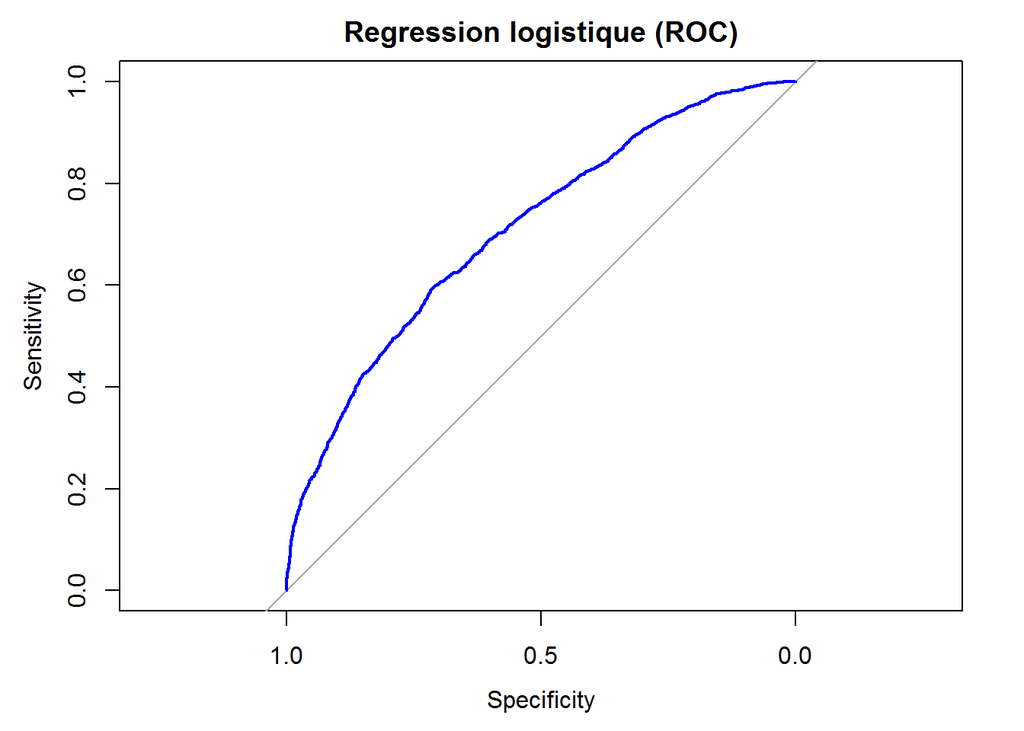

```r
library(pROC)
logit2.roc <- roc(mydata$goal_diff_class2[test], logit2.predict)
plot(logit2.roc,col="blue", lwd=2, xlim=c(1,0),main="Regression logistique (ROC)")
```

```r
logit2.roc$auc
```

```
## Area under the curve: 0.7091
```

## Modele 2 : Regression logistique avec régularisation LASSO

### Principe de modélisation

Nous restons dans le cadre de la régression logistique mais utilisons une procédure d’estimation différente afin de prévenir une éventuelle instabilité des paramètres susceptible de détériorer son pouvoir prédictif. De plus, et au vu du nombre relativement important de prédicteurs, la régression logistique standard est difficile à interpréter. Il existe de nombreuses alternatives pour effectuer de la sélection de variables (sélection de modèles, réduction de la dimension et régularisation), nous retenons l’approche de régularisation LASSO qui vise à minimiser l’inverse de la log vraisemblance (L) tout en pénalisant la valeur absolue des parametres du modele. A l’inverse de la pénalisation ridge qui agit sur le carré des coefficients, la pénalisation LASSO permet l’annulation complète des paramètres relatifs aux variables les moins significatives.

$$L + \lambda \sum_{i=1}^p |\beta i|$$
Le paramètre de régularisation (*lambda*) est obtenu de façon à minimiser l’erreur de prédiction out of sample par validation croisée.

### Calibrage du modèle

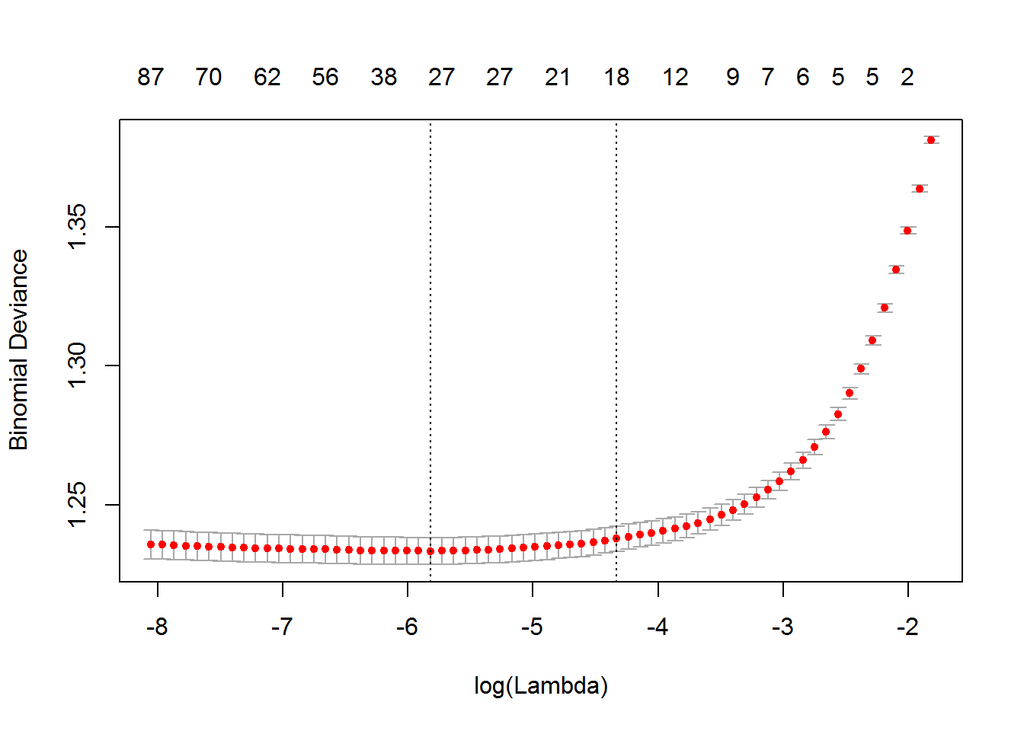

```r
library(glmnet)
set.seed(1)
mydata <-MCPT[,c(4,6:ncol(MCPT))]
x <- as.matrix(mydata[train,-1])
y <- mydata[train,1]
cvglmnet2 <- cv.glmnet(x,y,family="binomial",alpha=1)
plot(cvglmnet2)
```

```r
cvglmnet2$lambda.min
```

```
## [1] 0.002968226
```

```r
head(coef(cvglmnet2, s = "lambda.min"),15)
```

```
## 15 x 1 sparse Matrix of class "dgCMatrix"
##                          1
## (Intercept)   -0.469535278
## B365H         -0.196614030
## B365D          0.098757535
## B365A          0.082869860
## BWH           -0.065443479
## BWD            .
## BWA            0.003765174
## IWH            .
## IWD            .
## IWA            .
## LBH            .
## LBD            .
## LBA            .
## nbY234_home    .
## nbY91011_home  .
```

### Apprentissage

En échantillon d’apprentissage,la régression logistique avec régularisation LASSO donne des résultats comparables à ceux de la régression logistique standard. Le taux de bonne prévisons (0.6515) est tres legerement inferieur a celui de la regression logistique (0.6524)

```r
cvglmnet2.predclass <- predict(cvglmnet2, newx = as.matrix(mydata[train,-1]), type = "class", s = "lambda.min")
cvglmnet2.predprob <- predict(cvglmnet2, newx = as.matrix(mydata[train,-1]), type = "response", s = "lambda.min")
table(cvglmnet2.predclass,mydata$goal_diff_class2[train],dnn=c("prediction","reality"))
```

```
##                   reality
## prediction         1home_draworloss 2home_win
##   1home_draworloss             6238      3382
##   2home_win                    1950      3733
```

```r
mean(cvglmnet2.predclass==mydata$goal_diff_class2[train])
```

```
## [1] 0.6515716
```

### Test

En échantillon de test, les résultats sont légèrement améliorés avec un taux de bonne prévision égal à 0.6627 contre 0.6554 dans le cas de la régression logistique standard.

```r
cvglmnet2.predclass <- predict(cvglmnet2, newx = as.matrix(mydata[test,-1]), type = "class", s = "lambda.min")
cvglmnet2.predprob <- predict(cvglmnet2, newx = as.matrix(mydata[test,-1]), type = "response", s = "lambda.min")
table(cvglmnet2.predclass,mydata$goal_diff_class2[test],dnn=c("prediction","reality"))
```

```
##                   reality
## prediction         1home_draworloss 2home_win
##   1home_draworloss             2259      1140
##   2home_win                     600      1161
```

```r
mean(cvglmnet2.predclass==mydata$goal_diff_class2[test])
```

```
## [1] 0.6627907
```

### Courbe ROC

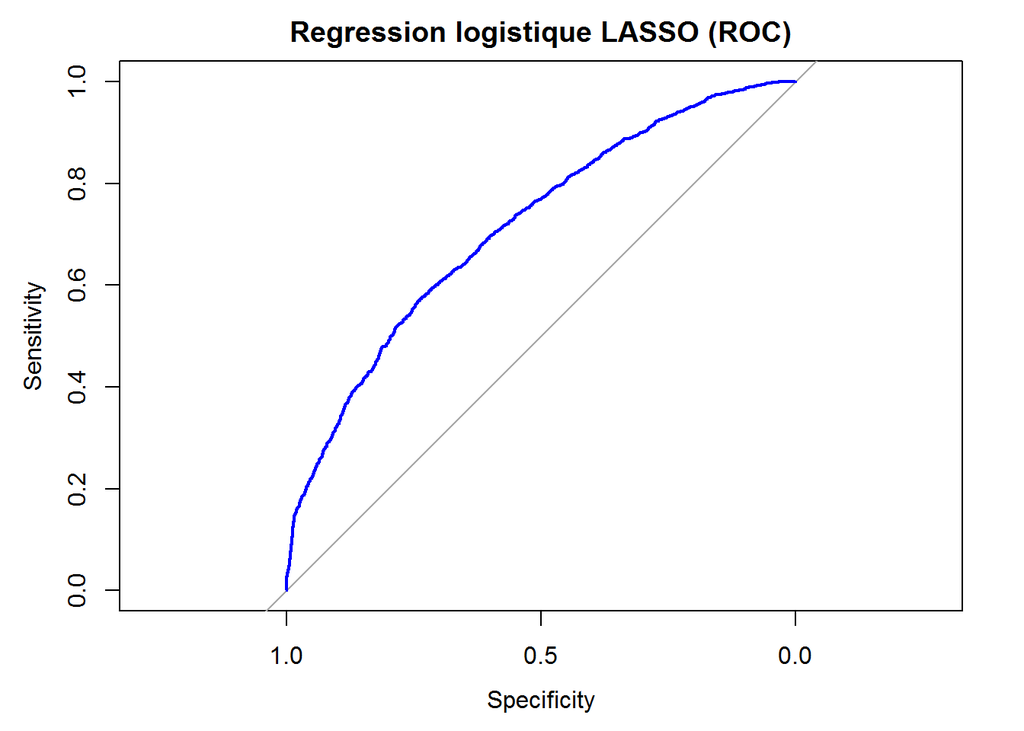

```r
library(pROC)
cvglmnet2.roc <- roc(mydata$goal_diff_class2[test], as.vector(cvglmnet2.predprob))
plot(cvglmnet2.roc,col="blue", lwd=2, xlim=c(1,0),main="Regression logistique LASSO (ROC)")
```

```r
cvglmnet2.roc$auc
```

```
## Area under the curve: 0.7141
```

## Modele 3 : Analyse linéaire discriminante (ALD)

### Principe de modélisation

L’analyse linéaire discriminante consiste à effectuer des hypothèses sur la distribution des prédicteurs à l’intérieur de chacune des classes - on suppose que le vecteur des prédicteurs *X = (X1, X2, …Xp)* suit une loi avec potentiellement des moyennes différentes pour chacune des deux classes mais des matrices de covariance identiques.
$$X =(X_1, X_2, ..., X_p) ~~suit~~ N(\mu_1, \Sigma)~~dans~la~classe~1~et~$$
$$X =(X_1, X_2, ..., X_p) ~~suit~~ N(\mu_2, \Sigma)~~dans~la~classe~2.$$
Le principe de l’ALD consiste à utiliser la règle de Bayes qui consiste à affecter un individu X = x à la classe k la plus probable (ici k = 1 ou 2) en tenant compte des probabilités d’appartenance aux classes a priori (frequences d’appartenance) et des densités de distributions pour chacune des classes.
$$Pr(Y = k/X = x)~=~\frac{\pi_k~f_k(x)}{\sum_{l=1}^2~\pi_l~f_l(x)}$$
En explicitant les calculs de densité on peut montrer que la règle de décision est linéaire en x, d’où le nom de la méthode.
$$\hat{\delta_k}(x) ~=~x~.~\frac{\hat{\mu_k}}{\hat{\sigma}^2}~-~ ~\frac{\hat{\mu_k}^2}{2\hat{\sigma}^2}~+~log(\hat{\pi_k})$$

### Calibrage du modèle

Le modele est estimé en utilisant la fonction *lda* du package *MASS*

```r
library(MASS)
mydata <- MCPT[,c(4,6:ncol(MCPT))]
lda2 <- lda(goal_diff_class2~., data=mydata,subset=train)
```

### Apprentissage

Avec un taux de bonne prévision de 0.6548, les résultats en apprentissage sont semblables à ceux obtenus pour les modèles de régression logistique standard et LASSO.

```r
lda2.predclass <- predict(lda2,mydata[train,])$class
lda2.predprob <- predict(lda2,mydata[train,])$posterior
table(lda2.predclass,mydata$goal_diff_class2[train],dnn=c("prediction","reality"))
```

```
##                   reality
## prediction         1home_draworloss 2home_win
##   1home_draworloss             6199      3293
##   2home_win                    1989      3822
```

```r
mean(lda2.predclass==mydata$goal_diff_class2[train])
```

```
## [1] 0.6548389
```

### Test

Ce taux de bonne prévision est très légèrement amélioré lors du passage à l’échantillon de test (0.6554 contre 0.6548), ce résultat est en ligne avec les performances des modèles présentés précédemment.

```r
lda2.predclass <- predict(lda2,mydata[test,])$class
lda2.predprob <- predict(lda2,mydata[test,])$posterior
table(lda2.predclass,mydata$goal_diff_class2[test],dnn=c("prediction","reality"))
```

```
##                   reality
## prediction         1home_draworloss 2home_win
##   1home_draworloss             2238      1157
##   2home_win                     621      1144
```

```r
mean(lda2.predclass==mydata$goal_diff_class2[test])
```

```
## [1] 0.6554264
```

### Courbe ROC

L’aire sous la courbe (auc) est de 0.7066 ce qui traduit un pouvoir prédictif similaire (quoi que légèrement inférieur) à ceux des modèles de régression logistique présentés précédemment. Ce résultat est en ligne avec la proximité méthodologique des méthodes d’analyse discriminante et de régression logistique.

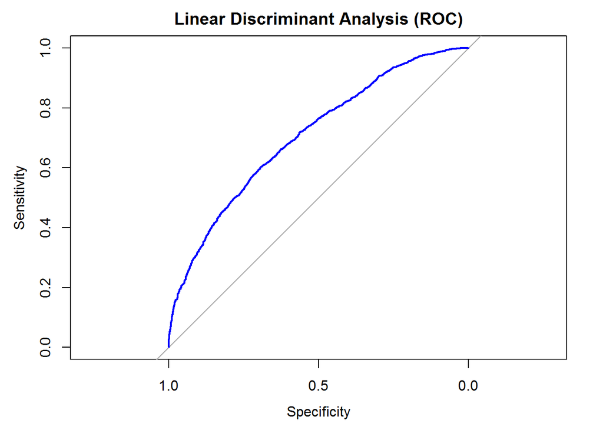

```r
library(pROC)
lda2.roc <- roc(mydata$goal_diff_class2[test], as.vector(lda2.predprob[,1]))
plot(lda2.roc,col="blue", lwd=2, xlim=c(1,0),main="Linear Discriminant Analysis (ROC)")
```

```r
lda2.roc$auc
```

```
## Area under the curve: 0.7066
```

## Modele 4 : Analyse quadratique discriminante (AQD)

### Principe de modélisation

L’analyse quadratique discriminante est proche l’analyse linéaire discriminante dans son principe : elle effectue des hypothèses sur la distribution conjointe des prédicteurs et utilise la règle de Bayes pour calculer des probabilités conditionnelles d’appartenance aux différentes classes. Tout comme l’ALD, l’AQD suppose que le vecteur des prédicteurs *X = (X1, X2, …Xp)* suit une loi multinormale à l’intérieur de chacune des classes. A la différence de l’ALD, l’AQD ne pose pas de restriction sur les matrices de covariance. Bien que restant dans le cadre de la normalité, les distributions des différentes classes peuvent avoir des paramètres de moyennes et de variance différents.

$$X =(X_1, X_2, ..., X_p) ~~suit~~ N(\mu_1, \Sigma_1)~~dans~la~classe~1~et~$$
$$X =(X_1, X_2, ..., X_p) ~~suit~~ N(\mu_2, \Sigma_2)~~dans~la~classe~2.$$

Tout comme pour l’ALD, le principe de l’ALD consiste à utiliser la règle de Bayes qui consiste à affecter un individu X = x à la classe k la plus probable (ici k = 1 ou 2) en tenant compte des probabilités d’appartenance aux classes a priori (frequences d’appartenance) et des densités de distributions pour chacune des classes.

$$Pr(Y = k/X = x)~=~\frac{\pi_k~f_k(x)}{\sum_{l=1}^2~\pi_l~f_l(x)}$$

En explicitant les calculs de densité (et du fait de matrices de covariance différentes), on calcule une règle de décision qui n’est plus une fonction linéaire mais plutôt une fonction quadratique des prédicteurs.

$$\delta_k(x) ~=~-\frac{1}{2}(x-\mu_k)^T\Sigma^{-1}_k(x-\mu_k)~-\frac{1}{2}log |\Sigma_k| +~log({\pi_k})$$

### Calibrage du modèle

L’estimation du modèele se fait en utilisant la fonction *qda* du package *MASS*

```r
library(MASS)
mydata <- MCPT[,c(4,6:ncol(MCPT))]
qda2 <- qda(goal_diff_class2~., data=mydata,subset=train)
```

### Apprentissage

Avec un taux de bonne prédiction, les résultats In Sample sont meilleurs que ceux obtenus avec les autres modèles présentés jusqu’ici.

```r
qda2.predclass <- predict(qda2,mydata[train,])$class
qda2.predprob <- predict(qda2,mydata[train,])$posterior
table(qda2.predclass,mydata$goal_diff_class2[train],dnn=c("prediction","reality"))
```

```
##                   reality
## prediction         1home_draworloss 2home_win
##   1home_draworloss             6380      2924
##   2home_win                    1808      4191
```

```r
mean(qda2.predclass==mydata$goal_diff_class2[train])
```

```
## [1] 0.6907796
```

### Test

malheureusement les résultats du modèle dans l’échantillon de test ne sont pas à la hauteur de ceux obtenus en apprentissage traduisant un sur-apprentissag du modèle.

```r
qda2.predclass <- predict(qda2,mydata[test,])$class
qda2.predprob <- predict(qda2,mydata[test,])$posterior
table(qda2.predclass,mydata$goal_diff_class2[test],dnn=c("prediction","reality"))
```

```
##                   reality
## prediction         1home_draworloss 2home_win
##   1home_draworloss             2164      1140
##   2home_win                     695      1161
```

```r
mean(qda2.predclass==mydata$goal_diff_class2[test])
```

```
## [1] 0.6443798
```

### Courbe ROC

L’AQD donne globalement des résultats légèrement moins bons que ceux obtenus par L’ALD. Le relâchement de l’hypothèse d’égalité des matrices de covariance entre les deux classes ne permet pas d’améliorer le pouvoir prédictif du modèle (auc = 0.6959).

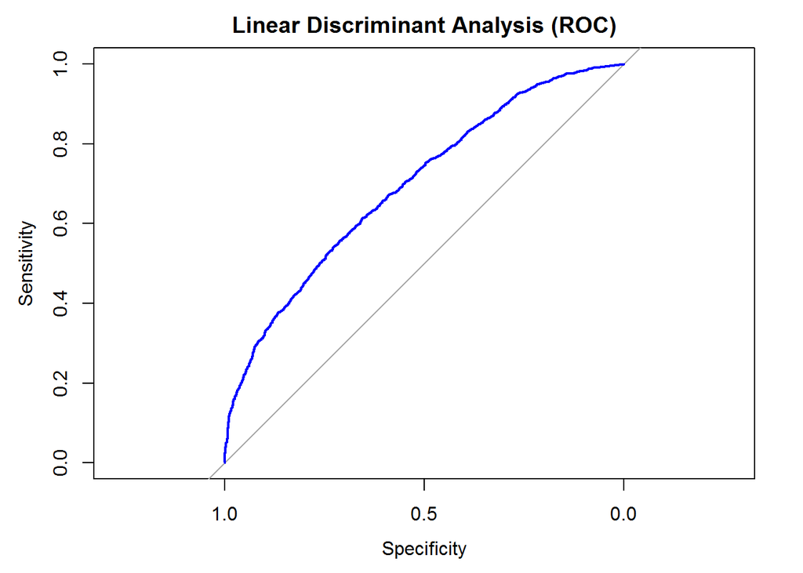

```r
library(pROC)
qda2.roc <- roc(mydata$goal_diff_class2[test], as.vector(qda2.predprob[,1]))
plot(qda2.roc,col="blue", lwd=2, xlim=c(1,0),main="Linear Discriminant Analysis (ROC)")
```

```r
qda2.roc$auc
```

```
## Area under the curve: 0.6959
```

## Modele 5 : k plus proches voisins (knn)

### Principe de modélisation

La méthode des k plus proches voisins est une méthode de classification non paramétrique. Pour un individu donné xo à classifier, le principe de l’algorithme consiste à identifier ses k plus proches voisins (en utilisant une métrique Euclidienne standard) et à affecter l’individu à la classe majoritairement représentée dans ce voisinage *No*.

$$Pr(Y=j/X=x_0)=\frac{1}{K}\sum_{i~\in~N_0}I(y_i=j)$$

### Calibrage du modele

Les prédicteurs sont standardisés pour éviter d’éventuels problèmes liés à l’échelle des variables dans le calcul des distances.

```r
library(class)
mydata.Y <-  MCPT[,4]
mydata.X <-  scale(MCPT[,c(6:ncol(MCPT))])
train.X <- mydata.X[train,]
test.X <-  mydata.X[test,]
train.Y <- mydata.Y[train]
test.Y <-  mydata.Y[test]
```

### Apprentissage

```r
set.seed(1)
knn2.predict = knn(train=train.X, test=train.X, cl=train.Y,k=100, prob=TRUE,use.all=TRUE)
table(knn2.predict,train.Y,dnn=c("prediction","reality"))
```

```
##                   reality
## prediction         1home_draworloss 2home_win
##   1home_draworloss             6332      3446
##   2home_win                    1856      3669
```

```r
mean(knn2.predict==train.Y)
```

```
## [1] 0.653532
```

### Test

```r
knn2.predict = knn(train=train.X, test=test.X, cl=train.Y,k=100, prob=TRUE,use.all=TRUE)
table(knn2.predict,test.Y,dnn=c("prediction","reality"))
```

```
##                   reality
## prediction         1home_draworloss 2home_win
##   1home_draworloss             2197      1173
##   2home_win                     662      1128
```

```r
mean(knn2.predict==test.Y)
```

```
## [1] 0.6443798
```

### Courbe ROC

La fonction knn ne retournant pas de probabilités d’appartenance aux différentes classes, un travail spécifique est nécessaire pour le calcul de la courbe ROC.

## Modele 6 : Arbre de décision

### Principe de modélisation

Les arbres de décision consistent à effectuer un partitionnement de l’espace des prédicteurs. Pour une nouvelle observation à classifier, la méthode consiste à identifier le segment d’espace auquel appartient cette observation et à lui affecter la classe majoritairement représentée au sein de ce segment. Les règles de décision successives visant partitionner l’espace des prédicteurs peuvent être représentées sous une forme d’arbre d’où l’appelation de la méthode. Bien que tres intuitive et simple à mettre en oeuvre, les arbres de décision souffrent généralement d’une forte instabilité et leur pouvoir prédictif est souvent limité. Cependant, les approches de bagging et de boosting permettent de pallier en considérant en utilisant l’arbre de décision comme une brique élémentaire d’une approche plus large.

### Calibrage du modèle

Le calibrage du modele est fait en utilisant la fonction *tree* du package *tree*. L’arbre obtenu met en évidence le rôle prépondérant joué par la variable B365H (Odds ratio de l’équipe à domicile pour le bokmaker Bet 365) qui est le seul prédicteur à intégrer le modèle. Ceci illustre bien la nécessité de “forcer” le modèle à considérer les autres prédicteurs.

```r
library(tree)
mydata <- MCPT[,c(4,6:ncol(MCPT))]
tree2.fit <-tree(goal_diff_class2~.,data=mydata,subset=train,split=c("deviance","gini"))
summary(tree2.fit)
```

```
##
## Classification tree:
## tree(formula = goal_diff_class2 ~ ., data = mydata, subset = train,
##     split = c("deviance", "gini"))
## Variables actually used in tree construction:
## [1] "B365H"
## Number of terminal nodes:  3
## Residual mean deviance:  1.259 = 19260 / 15300
## Misclassification error rate: 0.3533 = 5407 / 15303
```

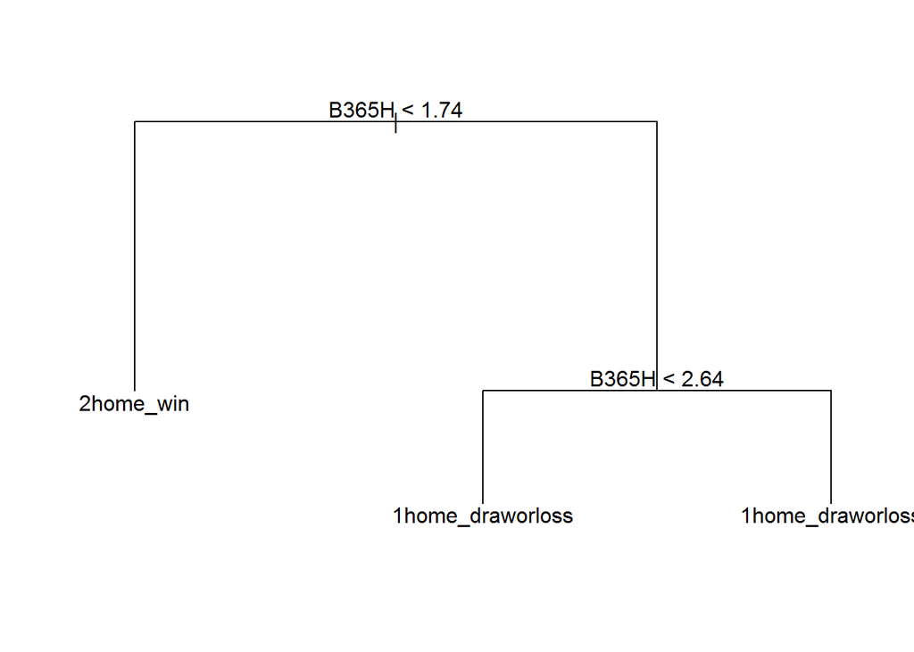

```r
plot(tree2.fit)
text(tree2.fit,pretty=0)
```

### Apprentissage

Il peut sembler surprenant de constater qu’un arbre de décision relativement simple (trois branches) donne des résultats proches de ceux obtenus avec des modélisations plus complexes.

```r
tree2.predclass <- predict(tree2.fit,mydata[train,],type="class")
tree2.predprob <- predict(tree2.fit,mydata[train,],type="vector")
table(tree2.predclass,mydata$goal_diff_class2[train],dnn=c("prediction","reality"))
```

```
##                   reality
## prediction         1home_draworloss 2home_win
##   1home_draworloss             6836      4055
##   2home_win                    1352      3060
```

```r
mean(tree2.predclass==mydata$goal_diff_class2[train])
```

```
## [1] 0.6466706
```

### Test

Avec un taux de bonne prédiction de 66%, ces résultats sont validés en échantillon de test

```r
tree2.predclass <- predict(tree2.fit,mydata[test,],type="class")
tree2.predprob <- predict(tree2.fit,mydata[test,],type="vector")
table(tree2.predclass,mydata$goal_diff_class2[test],dnn=c("prediction","reality"))
```

```
##                   reality
## prediction         1home_draworloss 2home_win
##   1home_draworloss             2427      1319
##   2home_win                     432       982
```

```r
mean(tree2.predclass==mydata$goal_diff_class2[test])
```

```
## [1] 0.6606589
```

### Courbe ROC

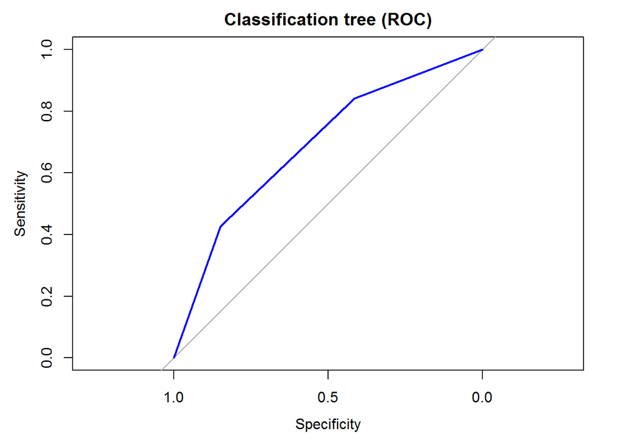

```r
library(pROC)
tree2.roc <- roc(mydata$goal_diff_class2[test], as.vector(tree2.predprob[,2]))
plot(tree2.roc,col="blue", lwd=2, xlim=c(1,0),main="Classification tree (ROC)")
```

```r
tree2.roc$auc
```

```
## Area under the curve: 0.689
```

## Modele 7 : Bagging d’arbres de décision

### Principe de modélisation

Nous utilisons le Bagging d’arbres comme un moyen de pallier le caractère instable de chaque arbre pris individuellement. La méthode consiste à utiliser les techniques de bootstrapping pour entraîner plusieurs arbres de décision sur des sous-échantillons différents de l’échantillon d’apprentissage. Les résultats des différents arbres sont ensuite agrégés et la classification finale se fait par un vote à la majorité. La procédure permet d’améliorer la qualité de la prédiction en réduisant la variance.

### Calibrage du modèle

Le modele est calibré en utilisant la fonction *randomForest* du )package *randomForest* avec le poaramètre *mtry* égal au nombre de prédicteurs (102 dans notre cas). Par défaut, le modèle considère 500 arbres construits à partir de l’ensemble complet des 102 prédicteurs.

```r
library(randomForest)
mydata <- MCPT[,c(4,6:ncol(MCPT))]
set.seed(1)
Bag2 <-randomForest(goal_diff_class2~.,data=mydata,subset=train,mtry=ncol(mydata)-1)
```

On mesure l’importance des prédicteurs en calculant la détérioration de la classification(sur la base de l’indice de pureté de Gini) liée à la suppression d’un indicateur. Même si la variable B365H n’est plus l’unique variable considérée, elle conserve cependant une importance prépondérante dans le modèle de bagging.

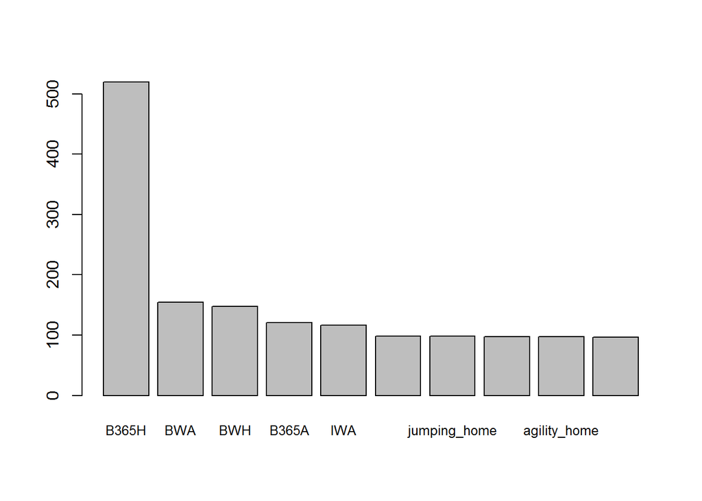

```r
barplot(head(Bag2$importance[order(Bag2$importance,decreasing=TRUE),],10),cex.names=0.8)
```

### Apprentissage

```r
Bag2.predclass <- predict(Bag2,data=mydata[train,],type="response")
Bag2.predprob <- predict(Bag2,data=mydata[train,],type="prob")
table(Bag2.predclass,mydata$goal_diff_class2[train],dnn=c("prediction","reality"))
```

```
##                   reality
## prediction         1home_draworloss 2home_win
##   1home_draworloss             5818      3163
##   2home_win                    2370      3952
```

```r
mean(Bag2.predclass==mydata$goal_diff_class2[train])
```

```
## [1] 0.6384369
```

### Test

```r
Bag2.predclass <- predict(Bag2,newdata=mydata[test,],type="response")
Bag2.predprob <- predict(Bag2,newdata=mydata[test,],type="prob")
table(Bag2.predclass,mydata$goal_diff_class2[test],dnn=c("prediction","reality"))
```

```
##                   reality
## prediction         1home_draworloss 2home_win
##   1home_draworloss             2158      1097
##   2home_win                     701      1204
```

```r
mean(Bag2.predclass==mydata$goal_diff_class2[test])
```

```
## [1] 0.6515504
```

### Courbe ROC

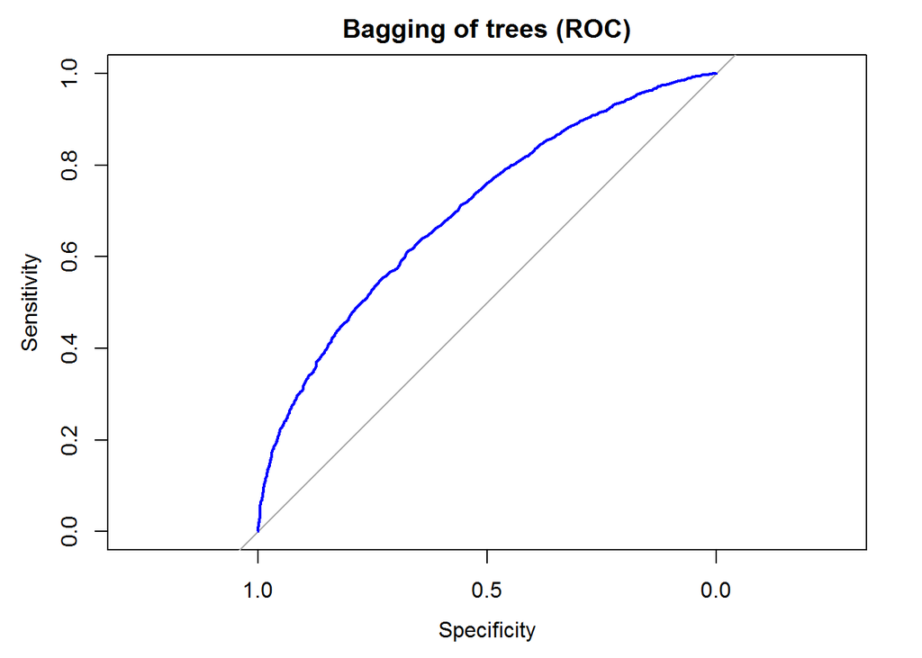

```r
library(pROC)
Bag2.roc <- roc(mydata$goal_diff_class2[test], Bag2.predprob[,2])
plot(Bag2.roc,col="blue", lwd=2, xlim=c(1,0),main="Bagging of trees (ROC)")
```

```r
Bag2.roc$auc
```

```
## Area under the curve: 0.7004
```

## Modele 8 : Forêt aléatoire

### Principe de modélisation

Le principe est similaire au bagging d’arbres, à la différence notable que dans le cas de la forêt aléatoire, un double tirage aléatoire est effectué pour chacun des arbres. En effet chaque arbre est entraîné à partir d’un ensemble restreint de variables choisies aléatoirement(10 dans le cas présent) et sur un échantillon bootstrap de l’échantillon d’apprentissage. Il en résulte une plus forte décorrélation des différents arbres dans la mesure où la nature du modèle garantit un “équilibre”" de l’importance relative des différents prédicteurs.

### Calibrage du modèle

Le modele est calibré en utilisant la fonction *randomForest* du package *randomForest* avec le poaramètre *mtry* égal à 10. Par défaut, le modèle considère 500 arbres construits à partir d’un ensemble de 10 prédicteurs al&atoirement sélectionnés parmi les 102 de départ.

```r
library(randomForest)
mydata <- MCPT[,c(4,6:ncol(MCPT))]
set.seed(1)
Forest2 <-randomForest(goal_diff_class2~.,data=mydata,subset=train,mtry=10)
```

L’indicateur d’importance des prédicteurs fait ressortir un meilleur équilibre des variables utilisées pour la construction des arbres. Le rôle dominant de la variable B365H est très largement atténué par la procédure de sélection aléatoire des prédicteurs.

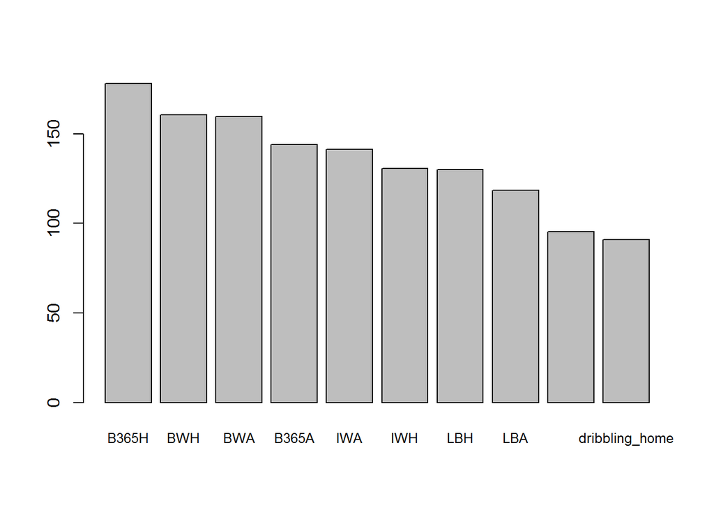

```r
barplot(head(Forest2$importance[order(Forest2$importance,decreasing=TRUE),],10),cex.names=0.8)
```

### Apprentissage

```r
Forest2.predclass <- predict(Forest2,data=mydata[train,],type="response")
Forest2.predprob <- predict(Forest2,data=mydata[train,],type="prob")
table(Forest2.predclass,mydata$goal_diff_class2[train],dnn=c("prediction","reality"))
```

```
##                   reality
## prediction         1home_draworloss 2home_win
##   1home_draworloss             5915      3184
##   2home_win                    2273      3931
```

```r
mean(Forest2.predclass==mydata$goal_diff_class2[train])
```

```
## [1] 0.6434033
```

### Test

```r
Forest2.predclass <- predict(Forest2,newdata=mydata[test,],type="response")
Forest2.predprob <- predict(Forest2,newdata=mydata[test,],type="prob")
table(Forest2.predclass,mydata$goal_diff_class2[test],dnn=c("prediction","reality"))
```

```
##                   reality
## prediction         1home_draworloss 2home_win
##   1home_draworloss             2177      1092
##   2home_win                     682      1209
```

```r
mean(Forest2.predclass==mydata$goal_diff_class2[test])
```

```
## [1] 0.6562016
```

### Courbe ROC

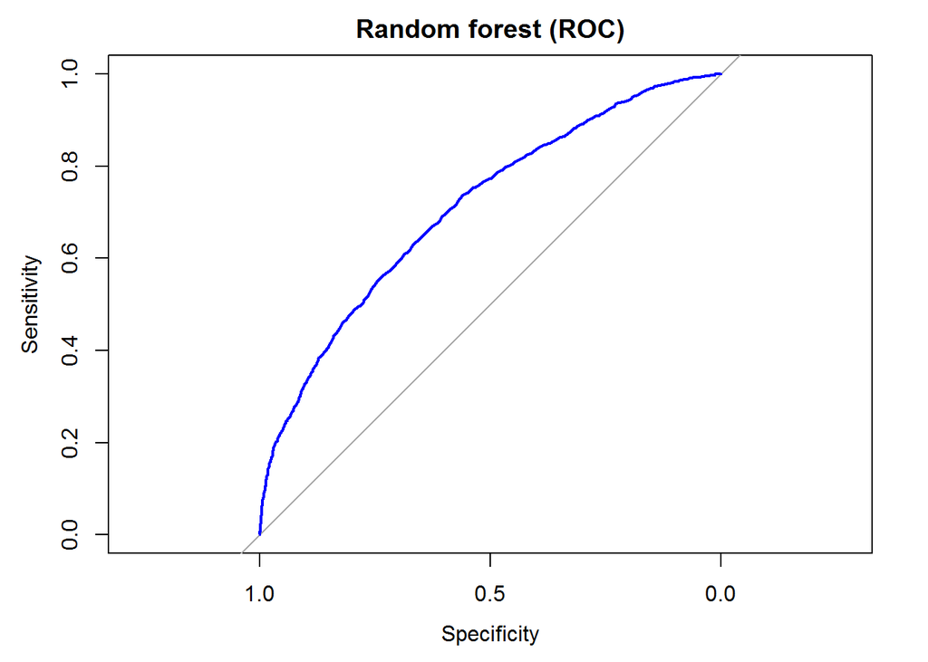

```r
library(pROC)
Forest2.roc <- roc(mydata$goal_diff_class2[test], Forest2.predprob[,2])
plot(Forest2.roc,col="blue", lwd=2, xlim=c(1,0),main="Random forest (ROC)")
```

```r
Forest2.roc$auc
```

```
## Area under the curve: 0.7094
```

## Modele 9 : Boosting d’arbres

### Principe de modélisation

Le principe général du boosting consiste à construire une famille d’estimateurs qui sont ensuite agrégés par une moyenne pondérée des estimations (en régression) ou un vote à la majorité (endiscrimination). Les estimateurs sont construits de manière récursive : chaque estimateur est uneversion adaptative du précédent en donnant plus de poids auxobservations mal ajustées ou mal prédites. L’estimateur construit à l’étape k concentrera donc ses efforts sur les observations mal ajustées par l’estimateur à l’étape k-1.Le terme boosting s’applique à des méthodes générales capables de produire des décisions très précises à partir de règles peu précises (qui font légèrement mieux que le hasard).

### Calibrage du modèle

Nous utilisons la fonction *boosting* du package *adabag*

```r
library(adabag)
mydata <- MCPT[,c(4,6:ncol(MCPT))]
set.seed(1)
adaboost2 <-boosting(goal_diff_class2~.,data=mydata[train,],boos=TRUE,coeflearn='Breiman')
```

### Apprentissage

```r
adaboost2.pred <- predict(adaboost2,newdata=mydata[train,])
table(adaboost2.pred$class,mydata$goal_diff_class2[train],dnn=c("prediction","reality"))
```

```
##                   reality
## prediction         1home_draworloss 2home_win
##   1home_draworloss             6105      3061
##   2home_win                    2083      4054
```

```r
mean(adaboost2.pred$class==mydata$goal_diff_class2[train])
```

```
## [1] 0.6638568
```

### Test

```r
adaboost2.pred <- predict(adaboost2,newdata=mydata[test,])
table(adaboost2.pred$class,mydata$goal_diff_class2[test],dnn=c("prediction","reality"))
```

```
##                   reality
## prediction         1home_draworloss 2home_win
##   1home_draworloss             2186      1102
##   2home_win                     673      1199
```

```r
mean(adaboost2.pred$class==mydata$goal_diff_class2[test])
```

```
## [1] 0.6560078
```

### Courbe de ROC

La qualité globale du modèle de boosting (auc=0.7104) est très légèrement supérieure à celle obtenu par les modèles de forêt aléatoire (auc=0.7094)

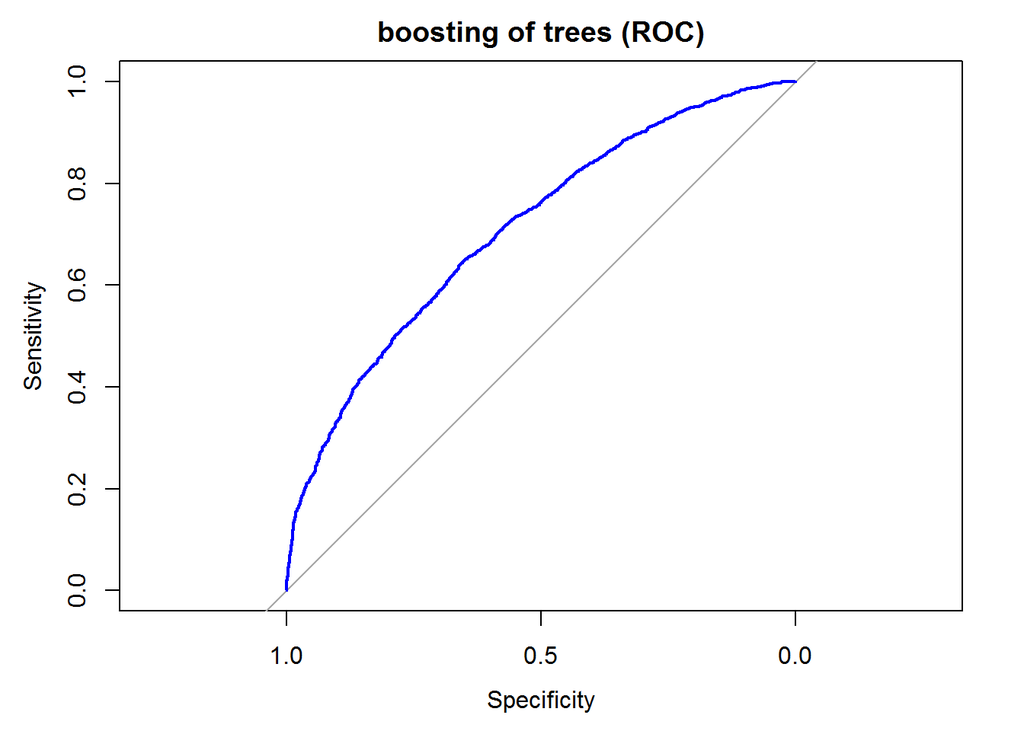

```r
library(pROC)
adaboost2.roc <- roc(mydata$goal_diff_class2[test], adaboost2.pred$prob[,2])
plot(adaboost2.roc,col="blue", lwd=2, xlim=c(1,0),main="boosting of trees (ROC)")
```

```r
adaboost2.roc$auc
```

```
## Area under the curve: 0.7104
```

## Modele 10 : Machine à vecteurs supports

### Principe de la méthode

Les SVM représentent une approche originale datant des années 1990. Le principe consite à trouver un hyperplan séparateur dans l’espace des prédicteurs et utiliser cet hyperplan comme une frontière de décision. Cet hyper plan est choisi de façon optimale afin que la règle de décision soit la plus stable possible. Dans le cas où les variables ne sont pas séparables linéairement, le kernel trick permet d’étendre l’espace des prédicteurs par des transformations fonctionnelles (polynomiale, radiale, …) et d’appliquer une séparation linéairedans un espace étendu, ce qui revient à appliquer une transformation non linéaire dans l’espace de départ.

### Calibrage du modèle

Le paramètre cost est obtenu par validation croisée en ulilisant la fonction tune.svm

```r
library(e1071)
mydata <- MCPT[,c(4,6:ncol(MCPT))]
set.seed(1)

SVMopt2 <-tune.svm(goal_diff_class2~.,data=mydata[minitrain,],kernel="linear",scale=TRUE,cost=10^(-4:1))
print(SVMopt2)
```

```
##
## Parameter tuning of 'svm':
##
## - sampling method: 10-fold cross validation
##
## - best parameters:
##   cost
##  0.001
##
## - best performance: 0.3616712
```

```r
SVM2 <-svm(goal_diff_class2~.,data=mydata,subset=train,kernel="linear",scale=TRUE,cost=0.001,decision.values=TRUE)
```

### Apprentissage

```r
SVM2.pred <- predict(SVM2,newdata=mydata[train,],decision.values = TRUE)
table(SVM2.pred,mydata$goal_diff_class2[train],dnn=c("prediction","reality"))
```

```
##                   reality
## prediction         1home_draworloss 2home_win
##   1home_draworloss             6957      4202
##   2home_win                    1231      2913
```

```r
mean(SVM2.pred==mydata$goal_diff_class2[train])
```

```
## [1] 0.6449716
```

### Test

```r
SVM2.pred <- predict(SVM2,newdata=mydata[test,],decision.values = TRUE)
table(SVM2.pred,mydata$goal_diff_class2[test],dnn=c("prediction","reality"))
```

```
##                   reality
## prediction         1home_draworloss 2home_win
##   1home_draworloss             2480      1402
##   2home_win                     379       899
```

```r
mean(SVM2.pred==mydata$goal_diff_class2[test])
```

```
## [1] 0.654845
```

### Courbe de ROC

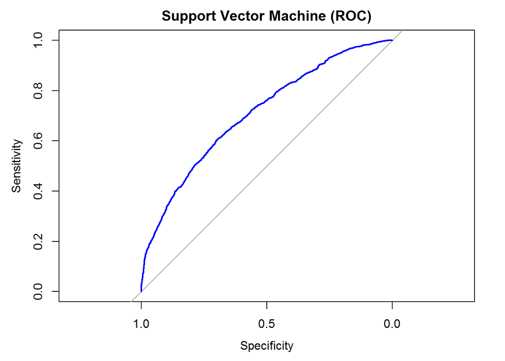

```r
library(pROC)
SVM2.roc <- roc(mydata$goal_diff_class2[test], as.vector(attr(SVM2.pred,"decision.values")))
plot(SVM2.roc,col="blue", lwd=2, xlim=c(1,0),main="Support Vector Machine (ROC)")
```

```r
SVM2.roc$auc
```

```
## Area under the curve: 0.7085
```

## Résultats de la modélisation

### Deux classes

- Avec des taux de bonne prédiction autour de 65% et des courbes ROC globalement similaires, tous les modèles donnent grosso modo des résultats comparables. Les taux de bonne prédiction obtenus sont à comparer à un benchmark de 54% pour le classifieur naïf consistant à systématiquement prédire la deuxième modalité (Pas de victoire à domicile).
- Le modèle de régression logistique avec pénalisation LASSO donne la meilleure qualité de prédiction tandis que le modèle d’analyse discriminante quadratique donne les moins bons résultats.
- Il est notable de constater que le modèle d’arbre de décision, bien que simpliste (un seul prédicteur pris en compte)affiche un taux de bonne prédiction en ligne, même si le modèle se classe en dernière position lorsque l’on considère le critère de l’auc.

[figure not shown]

```r
Resultats2 <- data.frame(c(0.7091,0.7141,0.7066,0.6959,NA,0.6853,0.7004,0.7094,0.7104,0.7085),c(0.6554,0.6627,0.6554,0.6443,0.6443,0.6606,0.6513,0.6562,0.6560,0.6548))
colnames(Resultats2) <- c("auc","accuracy")
rownames(Resultats2) <- c("log","lasso","lda","qda","knn","tree","bag","rndfrst","boost", "svm")
plot(Resultats2,xlim=c(0.68,0.72),ylim=c(0.64,0.67), main ="Resultats des modeles (2 classes)", col="blue")
text(Resultats2,label=row.names(Resultats2),cex=1,pos=1, col="blue")
```

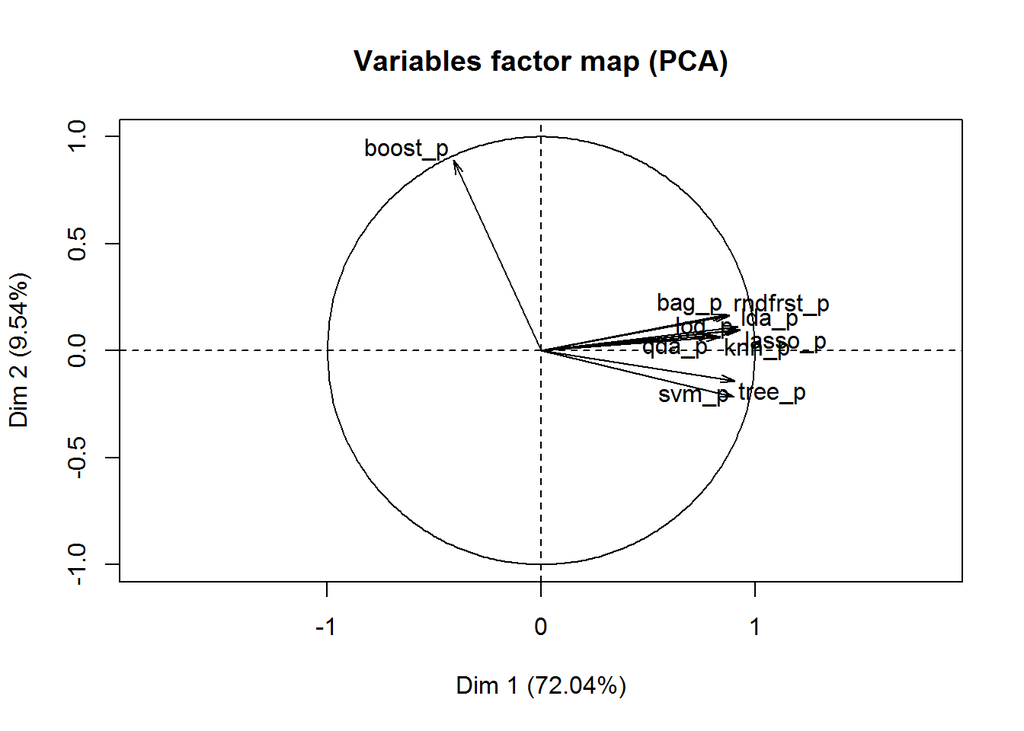

```r
library(FactoMineR)
acp <- PCA(Resultats_Test[,16:25],graph=FALSE)
plot.PCA(acp,choix="var")
```

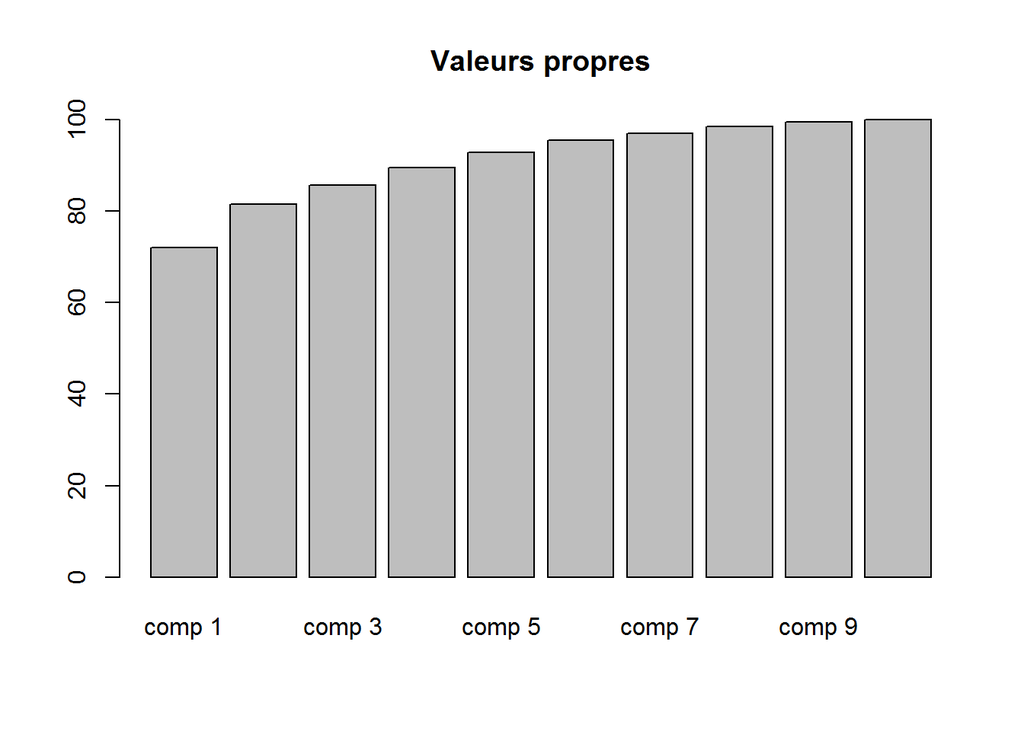

```r
barplot(acp$eig[,3],main="Valeurs propres")
```

```r
#summary(acp)
```

### Trois classes

- Avec un taux de bonne prédiction autour de 52%, le pouvoir prédictif de tous les modeles étudiés décroit significativement lorsque l’on considère une classification à trois modalités (Victoire à domicile, match nul, Défaite à domicile). Ceci témoigne de la difficulté à séparer les trois classes et en particulier la classe intermédiaire (match nul) à partir des prédicteurs considérés. Il faut cependant considérer qu’un modèle naïf consistantà prévoir systématiquement la victoire à domicile aurait un tauxs de bvonne prédiction égal à 46%.
- Les résultats des différents modèles sont relativement semblables avec un léger avantage encore une fois pour le modèle logistique avec régularisation LASSO.
- Le modèle d’analyse quadratique discriminante affiche des résultats très inférieurs aux autre modèles et très inférieurs à ceux obtenus par le modèle d’analyse linéaire discriminante. Ceci remet en cause l’hypothèse de matrice de covariance spécifiques à l’intérieur des différentes clasees.

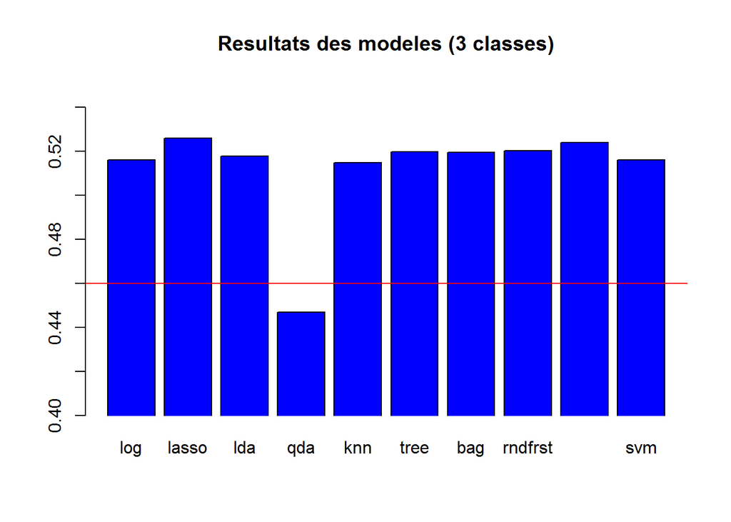

```r
Resultats3 <- data.frame(c(0.5162,0.5259,0.5178,0.4468,0.5149,0.5199,0.5196,0.5203,0.5240,0.5160))
colnames(Resultats3) <- "accuracy"
rownames(Resultats3) <- c("log","lasso","lda","qda","knn","tree","bag","rndfrst","boost", "svm")
barplot(Resultats3[,1], main ="Resultats des modeles (3 classes)", names.arg=row.names(Resultats3),col="blue",ylim=c(0.40,.55),xpd=FALSE)
abline(h=0.46, col="red")
```

```r
# Stops parallel computing
stopCluster(cl)
```